# BLACK FRIDAY ML HACKATON

## Load packages and load data

```r
path <- "C:/Users/BTData/Documents/Projects/Black_Friday/"
setwd(path)
#load the package
library(data.table)
library(ggplot2)
library(gmodels)
#load data using fread
train <- fread("train.csv", stringsAsFactors = T)
test <- fread("test.csv", stringsAsFactors = T)
#No. of rows and columns in Train
dim(train)
```

```
[1] 550068     12
```

```r
#No. of rows and columns in Test
dim(test)
```

```
[1] 233599     11
```

```r
str(train)
```

```
Classes âdata.tableâ and 'data.frame':  550068 obs. of  12 variables:
 $ User_ID                   : int  1000001 1000001 1000001 1000001 1000002 1000003 1000004 1000004 1000004 1000005 ...
 $ Product_ID                : Factor w/ 3631 levels "P00000142","P00000242",..: 673 2377 853 829 2735 1832 1746 3321 3605 2632 ...
 $ Gender                    : Factor w/ 2 levels "F","M": 1 1 1 1 2 2 2 2 2 2 ...
 $ Age                       : Factor w/ 7 levels "0-17","18-25",..: 1 1 1 1 7 3 5 5 5 3 ...
 $ Occupation                : int  10 10 10 10 16 15 7 7 7 20 ...
 $ City_Category             : Factor w/ 3 levels "A","B","C": 1 1 1 1 3 1 2 2 2 1 ...
 $ Stay_In_Current_City_Years: Factor w/ 5 levels "0","1","2","3",..: 3 3 3 3 5 4 3 3 3 2 ...
 $ Marital_Status            : int  0 0 0 0 0 0 1 1 1 1 ...
 $ Product_Category_1        : int  3 1 12 12 8 1 1 1 1 8 ...
 $ Product_Category_2        : int  NA 6 NA 14 NA 2 8 15 16 NA ...
 $ Product_Category_3        : int  NA 14 NA NA NA NA 17 NA NA NA ...
 $ Purchase                  : int  8370 15200 1422 1057 7969 15227 19215 15854 15686 7871 ...
 - attr(*, ".internal.selfref")=<externalptr>
```

## First empty model

Mean model

```r
sub_mean <- data.frame(User_ID = test$User_ID, Product_ID = test$Product_ID, Purchase = mean(train$Purchase))
write.csv(sub_mean, file = "first_sub.csv", row.names = F)
```

## Basic summary statistics

```r
summary (train)
```

```
    User_ID            Product_ID     Gender        Age           Occupation
 Min.   :1000001   P00265242:  1880   F:135809   0-17 : 15102   Min.   : 0.000
 1st Qu.:1001516   P00025442:  1615   M:414259   18-25: 99660   1st Qu.: 2.000
 Median :1003077   P00110742:  1612              26-35:219587   Median : 7.000
 Mean   :1003029   P00112142:  1562              36-45:110013   Mean   : 8.077
 3rd Qu.:1004478   P00057642:  1470              46-50: 45701   3rd Qu.:14.000
 Max.   :1006040   P00184942:  1440              51-55: 38501   Max.   :20.000
                   (Other)  :540489              55+  : 21504
 City_Category Stay_In_Current_City_Years Marital_Status   Product_Category_1
 A:147720      0 : 74398                  Min.   :0.0000   Min.   : 1.000
 B:231173      1 :193821                  1st Qu.:0.0000   1st Qu.: 1.000
 C:171175      2 :101838                  Median :0.0000   Median : 5.000
               3 : 95285                  Mean   :0.4097   Mean   : 5.404
               4+: 84726                  3rd Qu.:1.0000   3rd Qu.: 8.000
                                          Max.   :1.0000   Max.   :20.000

 Product_Category_2 Product_Category_3    Purchase
 Min.   : 2.00      Min.   : 3.0       Min.   :   12
 1st Qu.: 5.00      1st Qu.: 9.0       1st Qu.: 5823
 Median : 9.00      Median :14.0       Median : 8047
 Mean   : 9.84      Mean   :12.7       Mean   : 9264
 3rd Qu.:15.00      3rd Qu.:16.0       3rd Qu.:12054
 Max.   :18.00      Max.   :18.0       Max.   :23961
 NA's   :173638     NA's   :383247
```

```r
summary (test)
```

```
    User_ID            Product_ID     Gender        Age          Occupation
 Min.   :1000001   P00265242:   829   F: 57827   0-17 : 6232   Min.   : 0.000
 1st Qu.:1001527   P00112142:   717   M:175772   18-25:42293   1st Qu.: 2.000
 Median :1003070   P00025442:   695              26-35:93428   Median : 7.000
 Mean   :1003029   P00110742:   680              36-45:46711   Mean   : 8.085
 3rd Qu.:1004477   P00046742:   646              46-50:19577   3rd Qu.:14.000
 Max.   :1006040   P00184942:   626              51-55:16283   Max.   :20.000
                   (Other)  :229406              55+  : 9075
 City_Category Stay_In_Current_City_Years Marital_Status   Product_Category_1
 A:62524       0 :31318                   Min.   :0.0000   Min.   : 1.000
 B:98566       1 :82604                   1st Qu.:0.0000   1st Qu.: 1.000
 C:72509       2 :43589                   Median :0.0000   Median : 5.000
               3 :40143                   Mean   :0.4101   Mean   : 5.277
               4+:35945                   3rd Qu.:1.0000   3rd Qu.: 8.000
                                          Max.   :1.0000   Max.   :18.000

 Product_Category_2 Product_Category_3
 Min.   : 2.00      Min.   : 3.00
 1st Qu.: 5.00      1st Qu.: 9.00
 Median : 9.00      Median :14.00
 Mean   : 9.85      Mean   :12.67
 3rd Qu.:15.00      3rd Qu.:16.00
 Max.   :18.00      Max.   :18.00
 NA's   :72344      NA's   :162562
```

Summary statistic on target variable

```r
summary(train$Purchase)
```

```
   Min. 1st Qu.  Median    Mean 3rd Qu.    Max.
     12    5823    8047    9264   12050   23960
```

```r
sd(train$Purchase)
```

```
[1] 5023.065
```

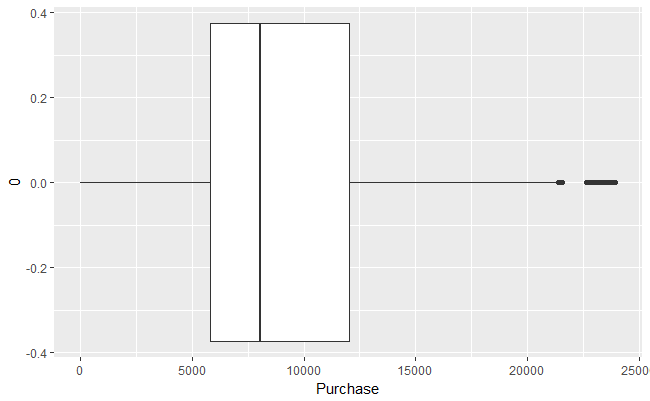

```r
ggplot(train, aes(x=0,y=Purchase))+geom_boxplot()+ coord_flip()
```

combine data set

```r
test[,Purchase := mean(train$Purchase)]
```

| User_ID | Product_ID | Gender | Age | Occupation | City_Category | Stay_In_Current_City_Years | Marital_Status | Product_Category_1 | Product_Category_2 | Product_Category_3 | Purchase |
| --- | --- | --- | --- | --- | --- | --- | --- | --- | --- | --- | --- |
| 1000004 | P00128942 | M | 46-50 | 7 | B | 2 | 1 | 1 | 11 | NA | 9263.969 |
| 1000009 | P00113442 | M | 26-35 | 17 | C | 0 | 0 | 3 | 5 | NA | 9263.969 |
| 1000010 | P00288442 | F | 36-45 | 1 | B | 4+ | 1 | 5 | 14 | NA | 9263.969 |
| 1000010 | P00145342 | F | 36-45 | 1 | B | 4+ | 1 | 4 | 9 | NA | 9263.969 |
| 1000011 | P00053842 | F | 26-35 | 1 | C | 1 | 0 | 4 | 5 | 12 | 9263.969 |
| 1000013 | P00350442 | M | 46-50 | 1 | C | 3 | 1 | 2 | 3 | 15 | 9263.969 |
| 1000013 | P00155442 | M | 46-50 | 1 | C | 3 | 1 | 1 | 11 | 15 | 9263.969 |
| 1000013 | P0094542 | M | 46-50 | 1 | C | 3 | 1 | 2 | 4 | 9 | 9263.969 |
| 1000015 | P00161842 | M | 26-35 | 7 | A | 1 | 0 | 10 | 13 | 16 | 9263.969 |
| 1000022 | P00067942 | M | 18-25 | 15 | A | 4+ | 0 | 5 | 14 | NA | 9263.969 |

[output cut: 990 more lines]

```r
c <- list(train, test)
combin <- rbindlist(c)
```

## Univariate exploratory analysis

```r
#analyzing gender variable
combin[,prop.table(table(Gender))]
```

```
Gender
        F         M
0.2470896 0.7529104
```

```r
#Age Variable
combin[,prop.table(table(Age))]
```

```
Age
      0-17      18-25      26-35      36-45      46-50      51-55        55+
0.02722330 0.18113944 0.39942348 0.19998801 0.08329814 0.06990724 0.03902040
```

```r
#City Category Variable
combin[,prop.table(table(City_Category))]
```

```
City_Category
        A         B         C
0.2682823 0.4207642 0.3109535
```

```r
#Stay in Current Years Variable
combin[,prop.table(table(Stay_In_Current_City_Years))]
```

```
Stay_In_Current_City_Years
        0         1         2         3        4+
0.1348991 0.3527327 0.1855724 0.1728132 0.1539825
```

```r
#unique values in ID variables
length(unique(combin$Product_ID))
```

```
[1] 3677
```

```r
length(unique(combin$User_ID))
```

```
[1] 5891
```

```r
#missing values
colSums(is.na(combin))
```

```
                   User_ID                 Product_ID                     Gender
                         0                          0                          0
                       Age                 Occupation              City_Category
                         0                          0                          0
Stay_In_Current_City_Years             Marital_Status         Product_Category_1
                         0                          0                          0
        Product_Category_2         Product_Category_3                   Purchase
                    245982                     545809                          0
```

## Bivariate exploratory analysis

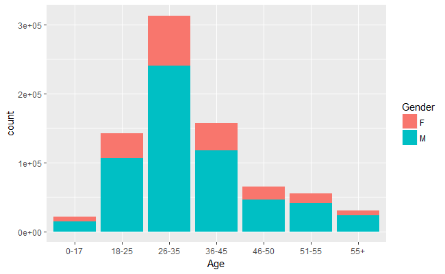

```r
#Age vs Gender
ggplot(combin, aes(Age, fill = Gender)) + geom_bar()
```

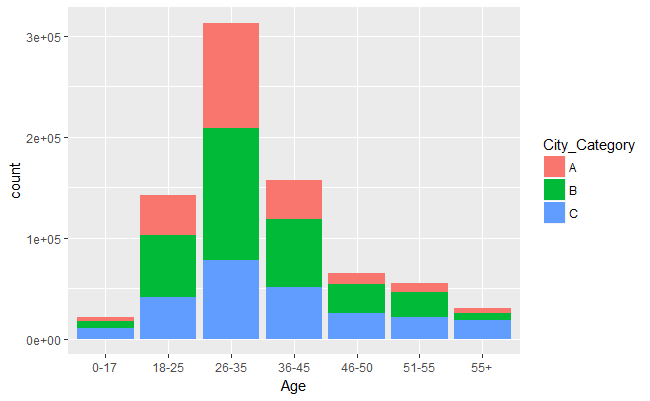

```r
#Age vs City_Category
ggplot(combin, aes(Age, fill = City_Category)) + geom_bar()
```

```r
CrossTable(combin$Occupation, combin$City_Category)
```

```
   Cell Contents
|-------------------------|
|                       N |
| Chi-square contribution |
|           N / Row Total |
|           N / Col Total |
|         N / Table Total |
|-------------------------|


Total Observations in Table:  783667


                  | combin$City_Category
combin$Occupation |         A |         B |         C | Row Total |
------------------|-----------|-----------|-----------|-----------|
                0 |     26874 |     42455 |     29521 |     98850 |
                  |     4.733 |    17.884 |    48.165 |           |
                  |     0.272 |     0.429 |     0.299 |     0.126 |
                  |     0.128 |     0.129 |     0.121 |           |
                  |     0.034 |     0.054 |     0.038 |           |
------------------|-----------|-----------|-----------|-----------|
                1 |     18200 |     28264 |     21223 |     67687 |
                  |     0.092 |     1.642 |     1.463 |           |
                  |     0.269 |     0.418 |     0.314 |     0.086 |
                  |     0.087 |     0.086 |     0.087 |           |
                  |     0.023 |     0.036 |     0.027 |           |
------------------|-----------|-----------|-----------|-----------|
                2 |     13201 |     16276 |      8519 |     37996 |
                  |   887.231 |     5.211 |   919.471 |           |
                  |     0.347 |     0.428 |     0.224 |     0.048 |
                  |     0.063 |     0.049 |     0.035 |           |
                  |     0.017 |     0.021 |     0.011 |           |
------------------|-----------|-----------|-----------|-----------|
                3 |      8040 |      9747 |      7339 |     25126 |
                  |   250.378 |    64.398 |    28.759 |           |
                  |     0.320 |     0.388 |     0.292 |     0.032 |
                  |     0.038 |     0.030 |     0.030 |           |
                  |     0.010 |     0.012 |     0.009 |           |
------------------|-----------|-----------|-----------|-----------|
```

[output cut: 90 more lines]

```
               19 |      3165 |      4712 |      4042 |     11919 |
                  |     0.334 |    18.317 |    30.415 |           |
                  |     0.266 |     0.395 |     0.339 |     0.015 |
                  |     0.015 |     0.014 |     0.017 |           |
                  |     0.004 |     0.006 |     0.005 |           |
------------------|-----------|-----------|-----------|-----------|
               20 |     18070 |     20608 |      9162 |     47840 |
                  |  2135.562 |    11.381 |  2194.806 |           |
                  |     0.378 |     0.431 |     0.192 |     0.061 |
                  |     0.086 |     0.062 |     0.038 |           |
                  |     0.023 |     0.026 |     0.012 |           |
------------------|-----------|-----------|-----------|-----------|
     Column Total |    210244 |    329739 |    243684 |    783667 |
                  |     0.268 |     0.421 |     0.311 |           |
------------------|-----------|-----------|-----------|-----------|
```

# create a new variable for missing values

Let’s start with missing values. We saw Product_Category_2 and Product_Category_3 had a lot of missing values. To me, this suggests a hidden trend which can be mapped by creating a new variable. So, we’ll create a new variable which will capture NAs as 1 and non-NAs as 0 in the variables Product_Category_2 and Product_Category_3.

```r
combin[,Product_Category_2_NA := ifelse(sapply(combin$Product_Category_2, is.na) ==    TRUE,1,0)]
```

| User_ID | Product_ID | Gender | Age | Occupation | City_Category | Stay_In_Current_City_Years | Marital_Status | Product_Category_1 | Product_Category_2 | Product_Category_3 | Purchase | Product_Category_2_NA |
| --- | --- | --- | --- | --- | --- | --- | --- | --- | --- | --- | --- | --- |
| 1000001 | P00069042 | F | 0-17 | 10 | A | 2 | 0 | 3 | NA | NA | 8370 | 1 |
| 1000001 | P00248942 | F | 0-17 | 10 | A | 2 | 0 | 1 | 6 | 14 | 15200 | 0 |
| 1000001 | P00087842 | F | 0-17 | 10 | A | 2 | 0 | 12 | NA | NA | 1422 | 1 |
| 1000001 | P00085442 | F | 0-17 | 10 | A | 2 | 0 | 12 | 14 | NA | 1057 | 0 |
| 1000002 | P00285442 | M | 55+ | 16 | C | 4+ | 0 | 8 | NA | NA | 7969 | 1 |
| 1000003 | P00193542 | M | 26-35 | 15 | A | 3 | 0 | 1 | 2 | NA | 15227 | 0 |
| 1000004 | P00184942 | M | 46-50 | 7 | B | 2 | 1 | 1 | 8 | 17 | 19215 | 0 |
| 1000004 | P00346142 | M | 46-50 | 7 | B | 2 | 1 | 1 | 15 | NA | 15854 | 0 |
| 1000004 | P0097242 | M | 46-50 | 7 | B | 2 | 1 | 1 | 16 | NA | 15686 | 0 |
| 1000005 | P00274942 | M | 26-35 | 20 | A | 1 | 1 | 8 | NA | NA | 7871 | 1 |

[output cut: 990 more lines]

```r
combin[,Product_Category_3_NA := ifelse(sapply(combin$Product_Category_3, is.na) ==  TRUE,1,0)]
```

| User_ID | Product_ID | Gender | Age | Occupation | City_Category | Stay_In_Current_City_Years | Marital_Status | Product_Category_1 | Product_Category_2 | Product_Category_3 | Purchase | Product_Category_2_NA | Product_Category_3_NA |
| --- | --- | --- | --- | --- | --- | --- | --- | --- | --- | --- | --- | --- | --- |
| 1000001 | P00069042 | F | 0-17 | 10 | A | 2 | 0 | 3 | NA | NA | 8370 | 1 | 1 |
| 1000001 | P00248942 | F | 0-17 | 10 | A | 2 | 0 | 1 | 6 | 14 | 15200 | 0 | 0 |
| 1000001 | P00087842 | F | 0-17 | 10 | A | 2 | 0 | 12 | NA | NA | 1422 | 1 | 1 |
| 1000001 | P00085442 | F | 0-17 | 10 | A | 2 | 0 | 12 | 14 | NA | 1057 | 0 | 1 |
| 1000002 | P00285442 | M | 55+ | 16 | C | 4+ | 0 | 8 | NA | NA | 7969 | 1 | 1 |
| 1000003 | P00193542 | M | 26-35 | 15 | A | 3 | 0 | 1 | 2 | NA | 15227 | 0 | 1 |
| 1000004 | P00184942 | M | 46-50 | 7 | B | 2 | 1 | 1 | 8 | 17 | 19215 | 0 | 0 |
| 1000004 | P00346142 | M | 46-50 | 7 | B | 2 | 1 | 1 | 15 | NA | 15854 | 0 | 1 |
| 1000004 | P0097242 | M | 46-50 | 7 | B | 2 | 1 | 1 | 16 | NA | 15686 | 0 | 1 |
| 1000005 | P00274942 | M | 26-35 | 20 | A | 1 | 1 | 8 | NA | NA | 7871 | 1 | 1 |

[output cut: 990 more lines]

Let’s now impute the missing values with any arbitrary number. Let’s take -999

# impute missing values

```r
combin[,Product_Category_2 := ifelse(is.na(Product_Category_2) == TRUE, "-999",  Product_Category_2)]
```

| User_ID | Product_ID | Gender | Age | Occupation | City_Category | Stay_In_Current_City_Years | Marital_Status | Product_Category_1 | Product_Category_2 | Product_Category_3 | Purchase | Product_Category_2_NA | Product_Category_3_NA |
| --- | --- | --- | --- | --- | --- | --- | --- | --- | --- | --- | --- | --- | --- |
| 1000001 | P00069042 | F | 0-17 | 10 | A | 2 | 0 | 3 | -999 | NA | 8370 | 1 | 1 |
| 1000001 | P00248942 | F | 0-17 | 10 | A | 2 | 0 | 1 | 6 | 14 | 15200 | 0 | 0 |
| 1000001 | P00087842 | F | 0-17 | 10 | A | 2 | 0 | 12 | -999 | NA | 1422 | 1 | 1 |
| 1000001 | P00085442 | F | 0-17 | 10 | A | 2 | 0 | 12 | 14 | NA | 1057 | 0 | 1 |
| 1000002 | P00285442 | M | 55+ | 16 | C | 4+ | 0 | 8 | -999 | NA | 7969 | 1 | 1 |
| 1000003 | P00193542 | M | 26-35 | 15 | A | 3 | 0 | 1 | 2 | NA | 15227 | 0 | 1 |
| 1000004 | P00184942 | M | 46-50 | 7 | B | 2 | 1 | 1 | 8 | 17 | 19215 | 0 | 0 |
| 1000004 | P00346142 | M | 46-50 | 7 | B | 2 | 1 | 1 | 15 | NA | 15854 | 0 | 1 |
| 1000004 | P0097242 | M | 46-50 | 7 | B | 2 | 1 | 1 | 16 | NA | 15686 | 0 | 1 |
| 1000005 | P00274942 | M | 26-35 | 20 | A | 1 | 1 | 8 | -999 | NA | 7871 | 1 | 1 |

[output cut: 990 more lines]

```r
combin[,Product_Category_3 := ifelse(is.na(Product_Category_3) == TRUE, "-999",  Product_Category_3)]
```

| User_ID | Product_ID | Gender | Age | Occupation | City_Category | Stay_In_Current_City_Years | Marital_Status | Product_Category_1 | Product_Category_2 | Product_Category_3 | Purchase | Product_Category_2_NA | Product_Category_3_NA |
| --- | --- | --- | --- | --- | --- | --- | --- | --- | --- | --- | --- | --- | --- |
| 1000001 | P00069042 | F | 0-17 | 10 | A | 2 | 0 | 3 | -999 | -999 | 8370 | 1 | 1 |
| 1000001 | P00248942 | F | 0-17 | 10 | A | 2 | 0 | 1 | 6 | 14 | 15200 | 0 | 0 |
| 1000001 | P00087842 | F | 0-17 | 10 | A | 2 | 0 | 12 | -999 | -999 | 1422 | 1 | 1 |
| 1000001 | P00085442 | F | 0-17 | 10 | A | 2 | 0 | 12 | 14 | -999 | 1057 | 0 | 1 |
| 1000002 | P00285442 | M | 55+ | 16 | C | 4+ | 0 | 8 | -999 | -999 | 7969 | 1 | 1 |
| 1000003 | P00193542 | M | 26-35 | 15 | A | 3 | 0 | 1 | 2 | -999 | 15227 | 0 | 1 |
| 1000004 | P00184942 | M | 46-50 | 7 | B | 2 | 1 | 1 | 8 | 17 | 19215 | 0 | 0 |
| 1000004 | P00346142 | M | 46-50 | 7 | B | 2 | 1 | 1 | 15 | -999 | 15854 | 0 | 1 |
| 1000004 | P0097242 | M | 46-50 | 7 | B | 2 | 1 | 1 | 16 | -999 | 15686 | 0 | 1 |
| 1000005 | P00274942 | M | 26-35 | 20 | A | 1 | 1 | 8 | -999 | -999 | 7871 | 1 | 1 |

[output cut: 990 more lines]

Convert all possible variable to numeric

```r
#set column level
levels(combin$Stay_In_Current_City_Years)[levels(combin$Stay_In_Current_City_Years) ==  "4+"] <- "4"
#recoding age groups
levels(combin$Age)[levels(combin$Age) == "0-17"] <- 0
levels(combin$Age)[levels(combin$Age) == "18-25"] <- 1
levels(combin$Age)[levels(combin$Age) == "26-35"] <- 2
levels(combin$Age)[levels(combin$Age) == "36-45"] <- 3
levels(combin$Age)[levels(combin$Age) == "46-50"] <- 4
levels(combin$Age)[levels(combin$Age) == "51-55"] <- 5
levels(combin$Age)[levels(combin$Age) == "55+"] <- 6
#convert age to numeric
combin$Age <- as.numeric(combin$Age)
#convert Gender into numeric
combin[, Gender := as.numeric(as.factor(Gender)) - 1]
```

| User_ID | Product_ID | Gender | Age | Occupation | City_Category | Stay_In_Current_City_Years | Marital_Status | Product_Category_1 | Product_Category_2 | Product_Category_3 | Purchase | Product_Category_2_NA | Product_Category_3_NA |
| --- | --- | --- | --- | --- | --- | --- | --- | --- | --- | --- | --- | --- | --- |
| 1000001 | P00069042 | 0 | 1 | 10 | A | 2 | 0 | 3 | -999 | -999 | 8370 | 1 | 1 |
| 1000001 | P00248942 | 0 | 1 | 10 | A | 2 | 0 | 1 | 6 | 14 | 15200 | 0 | 0 |
| 1000001 | P00087842 | 0 | 1 | 10 | A | 2 | 0 | 12 | -999 | -999 | 1422 | 1 | 1 |
| 1000001 | P00085442 | 0 | 1 | 10 | A | 2 | 0 | 12 | 14 | -999 | 1057 | 0 | 1 |
| 1000002 | P00285442 | 1 | 7 | 16 | C | 4 | 0 | 8 | -999 | -999 | 7969 | 1 | 1 |
| 1000003 | P00193542 | 1 | 3 | 15 | A | 3 | 0 | 1 | 2 | -999 | 15227 | 0 | 1 |
| 1000004 | P00184942 | 1 | 5 | 7 | B | 2 | 1 | 1 | 8 | 17 | 19215 | 0 | 0 |
| 1000004 | P00346142 | 1 | 5 | 7 | B | 2 | 1 | 1 | 15 | -999 | 15854 | 0 | 1 |
| 1000004 | P0097242 | 1 | 5 | 7 | B | 2 | 1 | 1 | 16 | -999 | 15686 | 0 | 1 |
| 1000005 | P00274942 | 1 | 3 | 20 | A | 1 | 1 | 8 | -999 | -999 | 7871 | 1 | 1 |

[output cut: 990 more lines]

During univariate analysis, we discovered that ID variables have lesser unique values as compared to total observations in the data set. It means there are User_IDs or Product_IDs must have appeared repeatedly in this data set.

Let’s create a new variable which captures the count of these ID variables. Higher user count suggests that a particular user has purchased products multiple times. High product count suggests that a product has been purchased many a times, which shows its popularity.

```r
#User Count
combin[, User_Count := .N, by = User_ID]
```

| User_ID | Product_ID | Gender | Age | Occupation | City_Category | Stay_In_Current_City_Years | Marital_Status | Product_Category_1 | Product_Category_2 | Product_Category_3 | Purchase | Product_Category_2_NA | Product_Category_3_NA | User_Count |
| --- | --- | --- | --- | --- | --- | --- | --- | --- | --- | --- | --- | --- | --- | --- |
| 1000001 | P00069042 | 0 | 1 | 10 | A | 2 | 0 | 3 | -999 | -999 | 8370 | 1 | 1 | 47 |
| 1000001 | P00248942 | 0 | 1 | 10 | A | 2 | 0 | 1 | 6 | 14 | 15200 | 0 | 0 | 47 |
| 1000001 | P00087842 | 0 | 1 | 10 | A | 2 | 0 | 12 | -999 | -999 | 1422 | 1 | 1 | 47 |
| 1000001 | P00085442 | 0 | 1 | 10 | A | 2 | 0 | 12 | 14 | -999 | 1057 | 0 | 1 | 47 |
| 1000002 | P00285442 | 1 | 7 | 16 | C | 4 | 0 | 8 | -999 | -999 | 7969 | 1 | 1 | 107 |
| 1000003 | P00193542 | 1 | 3 | 15 | A | 3 | 0 | 1 | 2 | -999 | 15227 | 0 | 1 | 41 |
| 1000004 | P00184942 | 1 | 5 | 7 | B | 2 | 1 | 1 | 8 | 17 | 19215 | 0 | 0 | 15 |
| 1000004 | P00346142 | 1 | 5 | 7 | B | 2 | 1 | 1 | 15 | -999 | 15854 | 0 | 1 | 15 |
| 1000004 | P0097242 | 1 | 5 | 7 | B | 2 | 1 | 1 | 16 | -999 | 15686 | 0 | 1 | 15 |
| 1000005 | P00274942 | 1 | 3 | 20 | A | 1 | 1 | 8 | -999 | -999 | 7871 | 1 | 1 | 151 |

[output cut: 990 more lines]

```r
#Product Count
combin[, Product_Count := .N, by = Product_ID]
```

| User_ID | Product_ID | Gender | Age | Occupation | City_Category | Stay_In_Current_City_Years | Marital_Status | Product_Category_1 | Product_Category_2 | Product_Category_3 | Purchase | Product_Category_2_NA | Product_Category_3_NA | User_Count | Product_Count |
| --- | --- | --- | --- | --- | --- | --- | --- | --- | --- | --- | --- | --- | --- | --- | --- |
| 1000001 | P00069042 | 0 | 1 | 10 | A | 2 | 0 | 3 | -999 | -999 | 8370 | 1 | 1 | 47 | 344 |
| 1000001 | P00248942 | 0 | 1 | 10 | A | 2 | 0 | 1 | 6 | 14 | 15200 | 0 | 0 | 47 | 845 |
| 1000001 | P00087842 | 0 | 1 | 10 | A | 2 | 0 | 12 | -999 | -999 | 1422 | 1 | 1 | 47 | 150 |
| 1000001 | P00085442 | 0 | 1 | 10 | A | 2 | 0 | 12 | 14 | -999 | 1057 | 0 | 1 | 47 | 496 |
| 1000002 | P00285442 | 1 | 7 | 16 | C | 4 | 0 | 8 | -999 | -999 | 7969 | 1 | 1 | 107 | 283 |
| 1000003 | P00193542 | 1 | 3 | 15 | A | 3 | 0 | 1 | 2 | -999 | 15227 | 0 | 1 | 41 | 863 |
| 1000004 | P00184942 | 1 | 5 | 7 | B | 2 | 1 | 1 | 8 | 17 | 19215 | 0 | 0 | 15 | 2066 |
| 1000004 | P00346142 | 1 | 5 | 7 | B | 2 | 1 | 1 | 15 | -999 | 15854 | 0 | 1 | 15 | 826 |
| 1000004 | P0097242 | 1 | 5 | 7 | B | 2 | 1 | 1 | 16 | -999 | 15686 | 0 | 1 | 15 | 1304 |
| 1000005 | P00274942 | 1 | 3 | 20 | A | 1 | 1 | 8 | -999 | -999 | 7871 | 1 | 1 | 151 | 1139 |

[output cut: 990 more lines]

Also, we can calculate the mean purchase price of a product. Because, lower the purchase price, higher will be the chances of that product being bought or vice versa. Similarly, we can create another variable which maps the average purchase price by user i.e. how much purchase (on an average) is made by a user. Let’s do it.

```r
#Mean Purchase price of Product
combin[, Mean_Purchase_Product := mean(Purchase), by = Product_ID]
```

| User_ID | Product_ID | Gender | Age | Occupation | City_Category | Stay_In_Current_City_Years | Marital_Status | Product_Category_1 | Product_Category_2 | Product_Category_3 | Purchase | Product_Category_2_NA | Product_Category_3_NA | User_Count | Product_Count | Mean_Purchase_Product |
| --- | --- | --- | --- | --- | --- | --- | --- | --- | --- | --- | --- | --- | --- | --- | --- | --- |
| 1000001 | P00069042 | 0 | 1 | 10 | A | 2 | 0 | 3 | -999 | -999 | 8370 | 1 | 1 | 47 | 344 | 10984.216 |
| 1000001 | P00248942 | 0 | 1 | 10 | A | 2 | 0 | 1 | 6 | 14 | 15200 | 0 | 0 | 47 | 845 | 14104.532 |
| 1000001 | P00087842 | 0 | 1 | 10 | A | 2 | 0 | 12 | -999 | -999 | 1422 | 1 | 1 | 47 | 150 | 3806.237 |
| 1000001 | P00085442 | 0 | 1 | 10 | A | 2 | 0 | 12 | 14 | -999 | 1057 | 0 | 1 | 47 | 496 | 3895.399 |
| 1000002 | P00285442 | 1 | 7 | 16 | C | 4 | 0 | 8 | -999 | -999 | 7969 | 1 | 1 | 107 | 283 | 8136.920 |
| 1000003 | P00193542 | 1 | 3 | 15 | A | 3 | 0 | 1 | 2 | -999 | 15227 | 0 | 1 | 41 | 863 | 12866.175 |
| 1000004 | P00184942 | 1 | 5 | 7 | B | 2 | 1 | 1 | 8 | 17 | 19215 | 0 | 0 | 15 | 2066 | 14585.736 |
| 1000004 | P00346142 | 1 | 5 | 7 | B | 2 | 1 | 1 | 15 | -999 | 15854 | 0 | 1 | 15 | 826 | 12785.822 |
| 1000004 | P0097242 | 1 | 5 | 7 | B | 2 | 1 | 1 | 16 | -999 | 15686 | 0 | 1 | 15 | 1304 | 13938.233 |
| 1000005 | P00274942 | 1 | 3 | 20 | A | 1 | 1 | 8 | -999 | -999 | 7871 | 1 | 1 | 151 | 1139 | 8431.947 |

[output cut: 990 more lines]

```r
#Mean Purchase sum of User
combin[, Mean_Purchase_User := mean(Purchase), by = User_ID]
```

| User_ID | Product_ID | Gender | Age | Occupation | City_Category | Stay_In_Current_City_Years | Marital_Status | Product_Category_1 | Product_Category_2 | Product_Category_3 | Purchase | Product_Category_2_NA | Product_Category_3_NA | User_Count | Product_Count | Mean_Purchase_Product | Mean_Purchase_User |
| --- | --- | --- | --- | --- | --- | --- | --- | --- | --- | --- | --- | --- | --- | --- | --- | --- | --- |
| 1000001 | P00069042 | 0 | 1 | 10 | A | 2 | 0 | 3 | -999 | -999 | 8370 | 1 | 1 | 47 | 344 | 10984.216 | 9473.630 |
| 1000001 | P00248942 | 0 | 1 | 10 | A | 2 | 0 | 1 | 6 | 14 | 15200 | 0 | 0 | 47 | 845 | 14104.532 | 9473.630 |
| 1000001 | P00087842 | 0 | 1 | 10 | A | 2 | 0 | 12 | -999 | -999 | 1422 | 1 | 1 | 47 | 150 | 3806.237 | 9473.630 |
| 1000001 | P00085442 | 0 | 1 | 10 | A | 2 | 0 | 12 | 14 | -999 | 1057 | 0 | 1 | 47 | 496 | 3895.399 | 9473.630 |
| 1000002 | P00285442 | 1 | 7 | 16 | C | 4 | 0 | 8 | -999 | -999 | 7969 | 1 | 1 | 107 | 283 | 8136.920 | 10171.879 |
| 1000003 | P00193542 | 1 | 3 | 15 | A | 3 | 0 | 1 | 2 | -999 | 15227 | 0 | 1 | 41 | 863 | 12866.175 | 11043.966 |
| 1000004 | P00184942 | 1 | 5 | 7 | B | 2 | 1 | 1 | 8 | 17 | 19215 | 0 | 0 | 15 | 2066 | 14585.736 | 14382.131 |
| 1000004 | P00346142 | 1 | 5 | 7 | B | 2 | 1 | 1 | 15 | -999 | 15854 | 0 | 1 | 15 | 826 | 12785.822 | 14382.131 |
| 1000004 | P0097242 | 1 | 5 | 7 | B | 2 | 1 | 1 | 16 | -999 | 15686 | 0 | 1 | 15 | 1304 | 13938.233 | 14382.131 |
| 1000005 | P00274942 | 1 | 3 | 20 | A | 1 | 1 | 8 | -999 | -999 | 7871 | 1 | 1 | 151 | 1139 | 8431.947 | 8197.878 |

[output cut: 990 more lines]

Now, we are only left with one hot encoding of City_Category variable. This can be done in one line using library dummies.

```r
library(dummies)
combin <- dummy.data.frame(combin, names = c("City_Category"), sep = "_")
```

Before, proceeding to modeling stage, let’s check data types of variables once, and make the required changes, if necessary.

```r
#check classes of all variables
sapply(combin, class)
```

```
                   User_ID                 Product_ID                     Gender
                 "integer"                   "factor"                  "numeric"
                       Age                 Occupation            City_Category_A
                 "numeric"                  "integer"                  "integer"
           City_Category_B            City_Category_C Stay_In_Current_City_Years
                 "integer"                  "integer"                   "factor"
            Marital_Status         Product_Category_1         Product_Category_2
                 "integer"                  "integer"                "character"
        Product_Category_3                   Purchase      Product_Category_2_NA
               "character"                  "numeric"                  "numeric"
     Product_Category_3_NA                 User_Count              Product_Count
                 "numeric"                  "integer"                  "integer"
     Mean_Purchase_Product         Mean_Purchase_User
                 "numeric"                  "numeric"
```

```r
#converting Product Category 2 & 3
combin$Product_Category_2 <- as.integer(combin$Product_Category_2)
combin$Product_Category_3 <- as.integer(combin$Product_Category_3)
```

## Model Building using H2O

```r
#Divide into train and test
c.train <- combin[1:nrow(train),]
c.test <- combin[-(1:nrow(train)),]
```

As discovered in beginning that the variable Product_Category_1 in train has some noise. Let’s remove it as well by selecting all rows in Product_Category_1 upto 18, thereby dropping rows which has category level 19 & 20.

```r
c.train <- c.train[c.train$Product_Category_1 <= 18,]
```

```r
library(h2o)
```

To launch the H2O cluster, write -

```r
localH2O <- h2o.init(nthreads = -1)
```

```
H2O is not running yet, starting it now...

Note:  In case of errors look at the following log files:
    C:\Users\BTData\AppData\Local\Temp\RtmpuYbsn4/h2o_BTData_started_from_r.out
    C:\Users\BTData\AppData\Local\Temp\RtmpuYbsn4/h2o_BTData_started_from_r.err

java version "1.8.0_111"
Java(TM) SE Runtime Environment (build 1.8.0_111-b14)
Java HotSpot(TM) 64-Bit Server VM (build 25.111-b14, mixed mode)

Starting H2O JVM and connecting: . Connection successful!

R is connected to the H2O cluster:
    H2O cluster uptime:         3 seconds 280 milliseconds
    H2O cluster version:        3.10.0.8
    H2O cluster version age:    1 month and 29 days
    H2O cluster name:           H2O_started_from_R_BTData_zzm060
    H2O cluster total nodes:    1
    H2O cluster total memory:   1.75 GB
    H2O cluster total cores:    8
    H2O cluster allowed cores:  8
    H2O cluster healthy:        TRUE
    H2O Connection ip:          localhost
    H2O Connection port:        54321
    H2O Connection proxy:       NA
    R Version:                  R version 3.3.2 (2016-10-31)
```

This commands tell H2O to use all the CPUs on the machine, which is recommended. For larger data sets (say > 1,000,000 rows), h2o recommends running cluster on a server with high memory for optimal performance. Once the instance starts successfully, you can also check its status using:

```r
h2o.init()
```

```
 Connection successful!

R is connected to the H2O cluster:
    H2O cluster uptime:         3 seconds 843 milliseconds
    H2O cluster version:        3.10.0.8
    H2O cluster version age:    1 month and 29 days
    H2O cluster name:           H2O_started_from_R_BTData_zzm060
    H2O cluster total nodes:    1
    H2O cluster total memory:   1.75 GB
    H2O cluster total cores:    8
    H2O cluster allowed cores:  8
    H2O cluster healthy:        TRUE
    H2O Connection ip:          localhost
    H2O Connection port:        54321
    H2O Connection proxy:       NA
    R Version:                  R version 3.3.2 (2016-10-31)
```

Let’s now transfer the data from R to h2o instance. It can be accomplished using as.h2o command.

```r
#data to h2o cluster
train.h2o <- as.h2o(c.train)
test.h2o <- as.h2o(c.test)
```

Using column index, we need to identify variables to be used in modeling as follows:

```r
#check column index number
colnames(train.h2o)
```

```
 [1] "User_ID"                    "Product_ID"                 "Gender"
 [4] "Age"                        "Occupation"                 "City_Category_A"
 [7] "City_Category_B"            "City_Category_C"            "Stay_In_Current_City_Years"
[10] "Marital_Status"             "Product_Category_1"         "Product_Category_2"
[13] "Product_Category_3"         "Purchase"                   "Product_Category_2_NA"
[16] "Product_Category_3_NA"      "User_Count"                 "Product_Count"
[19] "Mean_Purchase_Product"      "Mean_Purchase_User"
```

```r
#dependent variable (Purchase)
y.dep <- 14
#independent variables (dropping ID variables)
x.indep <- c(3:13,15:20)
```

## Multiple Regression in H2O

Let’s start with Multiple Regression model.

```r
regression.model <- h2o.glm( y = y.dep, x = x.indep, training_frame = train.h2o, family = "gaussian")
h2o.performance(regression.model)
```

```
H2ORegressionMetrics: glm
** Reported on training data. **

MSE:  16710563
RMSE:  4087.856
MAE:  3219.644
RMSLE:  0.5782911
Mean Residual Deviance :  16710563
R^2 :  0.3261543
Null Deviance :1.353804e+13
Null D.o.F. :545914
Residual Deviance :9.122547e+12
Residual D.o.F. :545898
AIC :10628689
```

```r
#make predictions
predict.reg <- as.data.frame(h2o.predict(regression.model, test.h2o))
sub_reg <- data.frame(User_ID = test$User_ID, Product_ID = test$Product_ID, Purchase =  predict.reg$predict)
write.csv(sub_reg, file = "sub_reg.csv", row.names = F)
```

## Random Forest in H2O

```r
#Random Forest
system.time(
rforest.model <- h2o.randomForest(y=y.dep, x=x.indep, training_frame = train.h2o, ntrees = 3000, mtries = 3, max_depth = 4, seed = 1122)
)
```

```
   user  system elapsed
   2.72    0.74  253.39
```

```r
h2o.performance(rforest.model)
```

```
H2ORegressionMetrics: drf
** Reported on training data. **
** Metrics reported on Out-Of-Bag training samples **

MSE:  10313592
RMSE:  3211.478
MAE:  2474.475
RMSLE:  0.4989367
Mean Residual Deviance :  10313592
```

```r
#check variable importance
h2o.varimp(rforest.model)
```

```
Variable Importances:
                     variable     relative_importance scaled_importance percentage
1       Mean_Purchase_Product 8374838871719936.000000          1.000000   0.578557
2          Product_Category_1 3122691406036992.000000          0.372866   0.215724
3               Product_Count  752814150123520.000000          0.089890   0.052006
4          Product_Category_3  660127212371968.000000          0.078823   0.045603
5       Product_Category_3_NA  598853732532224.000000          0.071506   0.041370
6          Mean_Purchase_User  510516254474240.000000          0.060958   0.035268
7          Product_Category_2  227329783627776.000000          0.027144   0.015705
8       Product_Category_2_NA  161790562402304.000000          0.019319   0.011177
9                  User_Count   37968068739072.000000          0.004534   0.002623
10            City_Category_C   14259671007232.000000          0.001703   0.000985
11                     Gender    6826974773248.000000          0.000815   0.000472
12            City_Category_A    3471292760064.000000          0.000414   0.000240
13                        Age    1837161906176.000000          0.000219   0.000127
14                 Occupation    1217158316032.000000          0.000145   0.000084
15            City_Category_B     714970300416.000000          0.000085   0.000049
16 Stay_In_Current_City_Years      93598867456.000000          0.000011   0.000006
17             Marital_Status      50767474688.000000          0.000006   0.000004
```

```r
#making predictions on unseen data
system.time(predict.rforest <- as.data.frame(h2o.predict(rforest.model, test.h2o)))
```

```
   user  system elapsed
   0.33    0.01    9.13
```

```r
#writing submission file
sub_rf <- data.frame(User_ID = test$User_ID, Product_ID = test$Product_ID, Purchase =  predict.rforest$predict)
write.csv(sub_rf, file = "sub_rf.csv", row.names = F)
```

#### Grid selection of parameters for RF

```r
summary(grid)
```

[output not shown]

```
H2O Grid Details
================

Grid ID: Grid_DRF_c.train_model_R_1481294871531_1
Used hyper parameters:
  -  max_depth
  -  mtries
  -  ntrees
Number of models: 36
Number of failed models: 0

Hyper-Parameter Search Summary: ordered by increasing residual_deviance
  max_depth mtries ntrees
1         6     10   1500
2         6     10   1000
3         6     10    500
4         5     10   1000
5         5     10    500
                                          model_ids residual_deviance
1 Grid_DRF_c.train_model_R_1481294871531_1_model_35 6608312.206545381
2 Grid_DRF_c.train_model_R_1481294871531_1_model_23 6608617.184602565
3 Grid_DRF_c.train_model_R_1481294871531_1_model_11 6609951.587930138
4 Grid_DRF_c.train_model_R_1481294871531_1_model_22 6749054.407092528
5 Grid_DRF_c.train_model_R_1481294871531_1_model_10 6758383.687197073

---
   max_depth mtries ntrees
31         4      3    500
32         4      3   1500
33         4      3   1000
34         3      3    500
35         3      3   1000
36         3      3   1500
                                           model_ids
31  Grid_DRF_c.train_model_R_1481294871531_1_model_1
32 Grid_DRF_c.train_model_R_1481294871531_1_model_25
33 Grid_DRF_c.train_model_R_1481294871531_1_model_13
34  Grid_DRF_c.train_model_R_1481294871531_1_model_0
35 Grid_DRF_c.train_model_R_1481294871531_1_model_12
36 Grid_DRF_c.train_model_R_1481294871531_1_model_24
```

[output cut: 39 more lines]

```
  -  Grid_DRF_c.train_model_R_1481294871531_1_model_15
  -  Grid_DRF_c.train_model_R_1481294871531_1_model_28
  -  Grid_DRF_c.train_model_R_1481294871531_1_model_4
  -  Grid_DRF_c.train_model_R_1481294871531_1_model_16
  -  Grid_DRF_c.train_model_R_1481294871531_1_model_26
  -  Grid_DRF_c.train_model_R_1481294871531_1_model_14
  -  Grid_DRF_c.train_model_R_1481294871531_1_model_2
  -  Grid_DRF_c.train_model_R_1481294871531_1_model_1
  -  Grid_DRF_c.train_model_R_1481294871531_1_model_25
  -  Grid_DRF_c.train_model_R_1481294871531_1_model_13
  -  Grid_DRF_c.train_model_R_1481294871531_1_model_0
  -  Grid_DRF_c.train_model_R_1481294871531_1_model_12
  -  Grid_DRF_c.train_model_R_1481294871531_1_model_24

Number of failed models: 0
```

Try new forest with setted parameters max_depth 4 mtries 3 ntrees 500

```r
system.time(
rforest.model <- h2o.randomForest(y=y.dep, x=x.indep, training_frame = train.h2o, ntrees = 500, mtries = 3, max_depth = 4, seed = 1122)
)
```

```
   user  system elapsed
   0.91    0.24   47.45
```

```r
h2o.performance(rforest.model)
```

```
H2ORegressionMetrics: drf
** Reported on training data. **
** Metrics reported on Out-Of-Bag training samples **

MSE:  10464035
RMSE:  3234.816
MAE:  2489.859
RMSLE:  0.5017624
Mean Residual Deviance :  10464035
```

```r
#check variable importance
h2o.varimp(rforest.model)
```

```
Variable Importances:
                     variable     relative_importance scaled_importance
1       Mean_Purchase_Product 1336320421003264.000000          1.000000
2          Product_Category_1  495899272806400.000000          0.371093
3               Product_Count  135617535016960.000000          0.101486
4          Product_Category_3  107751585873920.000000          0.080633
5       Product_Category_3_NA  103084726419456.000000          0.077141
6          Mean_Purchase_User   86333355720704.000000          0.064605
7          Product_Category_2   42961119215616.000000          0.032149
8       Product_Category_2_NA   35139914563584.000000          0.026296
9                  User_Count    5485313916928.000000          0.004105
10            City_Category_C    2456793382912.000000          0.001838
11                     Gender    1143788797952.000000          0.000856
12            City_Category_A     594561335296.000000          0.000445
13                        Age     302257831936.000000          0.000226
```

[output cut: 22 more lines]

```r
#making predictions on unseen data
system.time(predict.rforest <- as.data.frame(h2o.predict(rforest.model, test.h2o)))
```

```
   user  system elapsed
   0.38    0.00    7.72
```

```r
#writing submission file
sub_rf <- data.frame(User_ID = test$User_ID, Product_ID = test$Product_ID, Purchase =  predict.rforest$predict)
write.csv(sub_rf, file = "sub_rf2.csv", row.names = F)
```

## GBM

```r
system.time(
gbm.model <- h2o.gbm(y=y.dep, x=x.indep, training_frame = train.h2o, ntrees = 1000, max_depth = 4, learn_rate = 0.01, seed = 1122)
)
```

[output not shown]

```r
h2o.performance (gbm.model)
```

[output not shown]

```r
#making prediction and writing submission file
predict.gbm <- as.data.frame(h2o.predict(gbm.model, test.h2o))
sub_gbm <- data.frame(User_ID = test$User_ID, Product_ID = test$Product_ID, Purchase = predict.gbm$predict)
write.csv(sub_gbm, file = "sub_gbm.csv", row.names = F)
```

# Deep learning models

```r
system.time(
             dlearning.model <- h2o.deeplearning(y = y.dep,
             x = x.indep,
             training_frame = train.h2o,
             epoch = 60,
             hidden = c(100,100),
             activation = "Rectifier",
             seed = 1122
             )
)
```

[output not shown]

Anyways, let’s check its performance.

```r
h2o.performance(dlearning.model)
```

[output not shown]

```r
#making predictions
predict.dl2 <- as.data.frame(h2o.predict(dlearning.model, test.h2o))

#create a data frame and writing submission file
sub_dlearning <- data.frame(User_ID = test$User_ID, Product_ID = test$Product_ID, Purchase = predict.dl2$predict)
write.csv(sub_dlearning, file = "sub_dlearning_new.csv", row.names = F)
```